# Name :- Vishal Ramashankar Yadav

```python
# old dataframe
df
```

|  | Company | Category | Product | Per Serve Size | Energy (kCal) | Carbohydrates (g) | Protein (g) | Fiber (g) | Sugar (g) | Total Fat (g) | Saturated Fat (g) | Trans Fat (g) | Cholesterol (mg) | Sodium (mg) |
| --- | --- | --- | --- | --- | --- | --- | --- | --- | --- | --- | --- | --- | --- | --- |
| 0 | Pizza Hut | All Meals | Corn n Cheese (Personal) | 143.5 g | 432.60 | 65.64 | 17.91 | 3.85 | 8.484333 | 10.93 | 5.14 | 0.16 | 16.19 | 499.720000 |
| 1 | Pizza Hut | All Meals | Country Feast (Personal) | 178 g | 407.60 | 67.11 | 16.73 | 7.19 | 8.484333 | 8.03 | 3.24 | 0.11 | 66.80 | 818.000000 |
| 2 | Pizza Hut | All Meals | Double Cheese (Personal) | 143 g | 423.33 | 59.97 | 18.26 | 3.49 | 8.484333 | 12.27 | 5.23 | 0.18 | 19.75 | 638.220000 |
| 3 | Pizza Hut | All Meals | Double Paneer Supreme (Personal) | 174.5 g | 474.03 | 52.86 | 20.07 | 3.79 | 8.484333 | 20.26 | 9.25 | 0.33 | 71.72 | 1128.110000 |
| 4 | Pizza Hut | All Meals | Farmer`s Pick (Personal) | 177 g | 408.16 | 53.93 | 19.91 | 2.46 | 8.484333 | 12.53 | 4.90 | 0.14 | 48.09 | 942.670000 |
| ... | ... | ... | ... | ... | ... | ... | ... | ... | ... | ... | ... | ... | ... | ... |
| 525 | Dominos | All Meals | CHICKEN WINGS | 174 | 352.90 | 24.50 | 35.30 | 5.76 | 10.400000 | 12.60 | 4.80 | 0.19 | 308.70 | 422.431578 |
| 526 | Dominos | All Meals | CRISPY CHICKEN STRIPS | 156 | 461.20 | 51.30 | 26.70 | 5.16 | 3.600000 | 13.90 | 4.30 | 0.17 | 713.07 | 422.431578 |
| 527 | Dominos | All Meals | ZINGY PARCEL CHICKEN | 210 | 667.50 | 17.30 | 19.20 | 16.92 | 10.600000 | 31.30 | 14.10 | 0.56 | 541.49 | 422.431578 |
| 528 | Dominos | All Meals | TACO MEXICANA - CHICKEN | 97 | 322.60 | 34.20 | 9.30 | 5.40 | 3.900000 | 16.50 | 4.50 | 0.18 | 564.30 | 422.431578 |
| 529 | Dominos | All Meals | CALZONE POCKETS - CHICKEN | 248 | 582.90 | 101.00 | 18.60 | 5.04 | 12.200000 | 11.60 | 4.20 | 0.17 | 1171.60 | 422.431578 |

530 rows × 14 columns

```python
# saving the dataframe in csv after removing
df.to_csv('Nutrition Value Dataset.csv')
```

```python
# for looking the current working directory
import os
os.getcwd()
```

```
'C:\\Users\\admin\\Downloads'
```

```python
# now opening a new files after removing a outlyiers
df1 = pd.read_csv('Nutrition Value Dataset.csv')
df1
```

|  | Unnamed: 0 | Company | Category | Product | Per Serve Size | Energy (kCal) | Carbohydrates (g) | Protein (g) | Fiber (g) | Sugar (g) | Total Fat (g) | Saturated Fat (g) | Trans Fat (g) | Cholesterol (mg) | Sodium (mg) |
| --- | --- | --- | --- | --- | --- | --- | --- | --- | --- | --- | --- | --- | --- | --- | --- |
| 0 | 0 | Pizza Hut | All Meals | Corn n Cheese (Personal) | 143.5 g | 432.60 | 65.64 | 17.91 | 3.85 | 8.484333 | 10.93 | 5.14 | 0.16 | 16.19 | 499.720000 |
| 1 | 1 | Pizza Hut | All Meals | Country Feast (Personal) | 178 g | 407.60 | 67.11 | 16.73 | 7.19 | 8.484333 | 8.03 | 3.24 | 0.11 | 66.80 | 818.000000 |
| 2 | 2 | Pizza Hut | All Meals | Double Cheese (Personal) | 143 g | 423.33 | 59.97 | 18.26 | 3.49 | 8.484333 | 12.27 | 5.23 | 0.18 | 19.75 | 638.220000 |
| 3 | 3 | Pizza Hut | All Meals | Double Paneer Supreme (Personal) | 174.5 g | 474.03 | 52.86 | 20.07 | 3.79 | 8.484333 | 20.26 | 9.25 | 0.33 | 71.72 | 1128.110000 |
| 4 | 4 | Pizza Hut | All Meals | Farmer`s Pick (Personal) | 177 g | 408.16 | 53.93 | 19.91 | 2.46 | 8.484333 | 12.53 | 4.90 | 0.14 | 48.09 | 942.670000 |
| ... | ... | ... | ... | ... | ... | ... | ... | ... | ... | ... | ... | ... | ... | ... | ... |
| 525 | 525 | Dominos | All Meals | CHICKEN WINGS | 174 | 352.90 | 24.50 | 35.30 | 5.76 | 10.400000 | 12.60 | 4.80 | 0.19 | 308.70 | 422.431578 |
| 526 | 526 | Dominos | All Meals | CRISPY CHICKEN STRIPS | 156 | 461.20 | 51.30 | 26.70 | 5.16 | 3.600000 | 13.90 | 4.30 | 0.17 | 713.07 | 422.431578 |
| 527 | 527 | Dominos | All Meals | ZINGY PARCEL CHICKEN | 210 | 667.50 | 17.30 | 19.20 | 16.92 | 10.600000 | 31.30 | 14.10 | 0.56 | 541.49 | 422.431578 |
| 528 | 528 | Dominos | All Meals | TACO MEXICANA - CHICKEN | 97 | 322.60 | 34.20 | 9.30 | 5.40 | 3.900000 | 16.50 | 4.50 | 0.18 | 564.30 | 422.431578 |
| 529 | 529 | Dominos | All Meals | CALZONE POCKETS - CHICKEN | 248 | 582.90 | 101.00 | 18.60 | 5.04 | 12.200000 | 11.60 | 4.20 | 0.17 | 1171.60 | 422.431578 |

530 rows × 15 columns

### NOW CREATING A BOXPLOT TO SEE THE DATA OUTLIYER PRESENTED OR NOT STILL IN DATA

#### HERE OUR DATA = DF1 NEW SAVED CSV FILE DATA FRAME

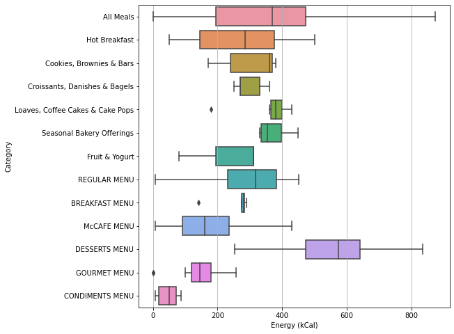

```python
plt.figure(figsize=(8,8))
plt.grid()
sns.boxplot(data=df1,x=y,y='Category')
```

```python
# info if new dataframe
df.describe()
```

|  | Energy (kCal) | Carbohydrates (g) | Protein (g) | Fiber (g) | Sugar (g) | Total Fat (g) | Saturated Fat (g) | Trans Fat (g) | Cholesterol (mg) | Sodium (mg) |
| --- | --- | --- | --- | --- | --- | --- | --- | --- | --- | --- |
| count | 530.000000 | 530.000000 | 530.000000 | 530.000000 | 530.000000 | 530.000000 | 530.000000 | 530.000000 | 530.000000 | 530.000000 |
| mean | 377.304470 | 39.442302 | 16.773636 | 4.970340 | 8.484333 | 13.228528 | 5.946302 | 0.282105 | 118.620434 | 422.431578 |
| std | 338.315722 | 21.196943 | 24.404082 | 6.182284 | 12.115622 | 10.740934 | 4.844024 | 3.265489 | 502.865434 | 430.805073 |
| min | 0.000000 | 0.000000 | 0.000000 | 0.000000 | 0.000000 | 0.000000 | 0.000000 | 0.000000 | 0.000000 | 0.000000 |
| 25% | 180.750000 | 24.227500 | 5.025000 | 1.690000 | 0.000000 | 5.000000 | 2.500000 | 0.040000 | 9.462500 | 14.135000 |
| 50% | 329.645000 | 38.570000 | 11.550000 | 3.000000 | 3.425000 | 12.600000 | 5.240000 | 0.120000 | 30.085000 | 422.431578 |
| 75% | 451.812500 | 54.120000 | 20.005000 | 5.997500 | 9.850000 | 18.360000 | 8.095000 | 0.210000 | 77.535000 | 679.650000 |
| max | 2880.000000 | 137.800000 | 203.000000 | 45.000000 | 64.220000 | 82.600000 | 33.000000 | 75.260000 | 9769.700000 | 2399.490000 |

```python
df1.select_dtypes([object])
```

|  | Company | Category | Product | Per Serve Size |
| --- | --- | --- | --- | --- |
| 0 | Pizza Hut | All Meals | Corn n Cheese (Personal) | 143.5 g |
| 1 | Pizza Hut | All Meals | Country Feast (Personal) | 178 g |
| 2 | Pizza Hut | All Meals | Double Cheese (Personal) | 143 g |
| 3 | Pizza Hut | All Meals | Double Paneer Supreme (Personal) | 174.5 g |
| 4 | Pizza Hut | All Meals | Farmer`s Pick (Personal) | 177 g |
| ... | ... | ... | ... | ... |
| 525 | Dominos | All Meals | CHICKEN WINGS | 174 |
| 526 | Dominos | All Meals | CRISPY CHICKEN STRIPS | 156 |
| 527 | Dominos | All Meals | ZINGY PARCEL CHICKEN | 210 |
| 528 | Dominos | All Meals | TACO MEXICANA - CHICKEN | 97 |
| 529 | Dominos | All Meals | CALZONE POCKETS - CHICKEN | 248 |

530 rows × 4 columns

```python
# numerical data list from datasets
df_num=df1.select_dtypes([int, float])
df_num
```

|  | Unnamed: 0 | Energy (kCal) | Carbohydrates (g) | Protein (g) | Fiber (g) | Sugar (g) | Total Fat (g) | Saturated Fat (g) | Trans Fat (g) | Cholesterol (mg) | Sodium (mg) |
| --- | --- | --- | --- | --- | --- | --- | --- | --- | --- | --- | --- |
| 0 | 0 | 432.60 | 65.64 | 17.91 | 3.85 | 8.484333 | 10.93 | 5.14 | 0.16 | 16.19 | 499.720000 |
| 1 | 1 | 407.60 | 67.11 | 16.73 | 7.19 | 8.484333 | 8.03 | 3.24 | 0.11 | 66.80 | 818.000000 |
| 2 | 2 | 423.33 | 59.97 | 18.26 | 3.49 | 8.484333 | 12.27 | 5.23 | 0.18 | 19.75 | 638.220000 |
| 3 | 3 | 474.03 | 52.86 | 20.07 | 3.79 | 8.484333 | 20.26 | 9.25 | 0.33 | 71.72 | 1128.110000 |
| 4 | 4 | 408.16 | 53.93 | 19.91 | 2.46 | 8.484333 | 12.53 | 4.90 | 0.14 | 48.09 | 942.670000 |
| ... | ... | ... | ... | ... | ... | ... | ... | ... | ... | ... | ... |
| 525 | 525 | 352.90 | 24.50 | 35.30 | 5.76 | 10.400000 | 12.60 | 4.80 | 0.19 | 308.70 | 422.431578 |
| 526 | 526 | 461.20 | 51.30 | 26.70 | 5.16 | 3.600000 | 13.90 | 4.30 | 0.17 | 713.07 | 422.431578 |
| 527 | 527 | 667.50 | 17.30 | 19.20 | 16.92 | 10.600000 | 31.30 | 14.10 | 0.56 | 541.49 | 422.431578 |
| 528 | 528 | 322.60 | 34.20 | 9.30 | 5.40 | 3.900000 | 16.50 | 4.50 | 0.18 | 564.30 | 422.431578 |
| 529 | 529 | 582.90 | 101.00 | 18.60 | 5.04 | 12.200000 | 11.60 | 4.20 | 0.17 | 1171.60 | 422.431578 |

530 rows × 11 columns

```python
df_category=df1.select_dtypes([object])
df_category
```

|  | Company | Category | Product | Per Serve Size |
| --- | --- | --- | --- | --- |
| 0 | Pizza Hut | All Meals | Corn n Cheese (Personal) | 143.5 g |
| 1 | Pizza Hut | All Meals | Country Feast (Personal) | 178 g |
| 2 | Pizza Hut | All Meals | Double Cheese (Personal) | 143 g |
| 3 | Pizza Hut | All Meals | Double Paneer Supreme (Personal) | 174.5 g |
| 4 | Pizza Hut | All Meals | Farmer`s Pick (Personal) | 177 g |
| ... | ... | ... | ... | ... |
| 525 | Dominos | All Meals | CHICKEN WINGS | 174 |
| 526 | Dominos | All Meals | CRISPY CHICKEN STRIPS | 156 |
| 527 | Dominos | All Meals | ZINGY PARCEL CHICKEN | 210 |
| 528 | Dominos | All Meals | TACO MEXICANA - CHICKEN | 97 |
| 529 | Dominos | All Meals | CALZONE POCKETS - CHICKEN | 248 |

530 rows × 4 columns

```python
df_category["Category"].unique()
```

```
array(['All Meals', 'Hot Breakfast', 'Cookies, Brownies & Bars',
       'Croissants, Danishes & Bagels',
       'Loaves, Coffee Cakes & Cake Pops', 'Seasonal Bakery Offerings',
       'Fruit & Yogurt', 'REGULAR MENU', 'BREAKFAST MENU', 'McCAFE MENU',
       'DESSERTS MENU', 'GOURMET MENU', 'CONDIMENTS MENU'], dtype=object)
```

## BY USING GET_DUMMIES WE READ THE DATA IN 0 , 1 FORMATE¶

```python
pd.get_dummies(df_category["Category"])
```

|  | All Meals | BREAKFAST MENU | CONDIMENTS MENU | Cookies, Brownies & Bars | Croissants, Danishes & Bagels | DESSERTS MENU | Fruit & Yogurt | GOURMET MENU | Hot Breakfast | Loaves, Coffee Cakes & Cake Pops | McCAFE MENU | REGULAR MENU | Seasonal Bakery Offerings |
| --- | --- | --- | --- | --- | --- | --- | --- | --- | --- | --- | --- | --- | --- |
| 0 | 1 | 0 | 0 | 0 | 0 | 0 | 0 | 0 | 0 | 0 | 0 | 0 | 0 |
| 1 | 1 | 0 | 0 | 0 | 0 | 0 | 0 | 0 | 0 | 0 | 0 | 0 | 0 |
| 2 | 1 | 0 | 0 | 0 | 0 | 0 | 0 | 0 | 0 | 0 | 0 | 0 | 0 |
| 3 | 1 | 0 | 0 | 0 | 0 | 0 | 0 | 0 | 0 | 0 | 0 | 0 | 0 |
| 4 | 1 | 0 | 0 | 0 | 0 | 0 | 0 | 0 | 0 | 0 | 0 | 0 | 0 |
| ... | ... | ... | ... | ... | ... | ... | ... | ... | ... | ... | ... | ... | ... |
| 525 | 1 | 0 | 0 | 0 | 0 | 0 | 0 | 0 | 0 | 0 | 0 | 0 | 0 |
| 526 | 1 | 0 | 0 | 0 | 0 | 0 | 0 | 0 | 0 | 0 | 0 | 0 | 0 |
| 527 | 1 | 0 | 0 | 0 | 0 | 0 | 0 | 0 | 0 | 0 | 0 | 0 | 0 |
| 528 | 1 | 0 | 0 | 0 | 0 | 0 | 0 | 0 | 0 | 0 | 0 | 0 | 0 |
| 529 | 1 | 0 | 0 | 0 | 0 | 0 | 0 | 0 | 0 | 0 | 0 | 0 | 0 |

530 rows × 13 columns

```python
df_num=df.select_dtypes([int, float])
df_num
```

|  | Energy (kCal) | Carbohydrates (g) | Protein (g) | Fiber (g) | Sugar (g) | Total Fat (g) | Saturated Fat (g) | Trans Fat (g) | Cholesterol (mg) | Sodium (mg) |
| --- | --- | --- | --- | --- | --- | --- | --- | --- | --- | --- |
| 0 | 432.60 | 65.64 | 17.91 | 3.85 | 8.484333 | 10.93 | 5.14 | 0.16 | 16.19 | 499.720000 |
| 1 | 407.60 | 67.11 | 16.73 | 7.19 | 8.484333 | 8.03 | 3.24 | 0.11 | 66.80 | 818.000000 |
| 2 | 423.33 | 59.97 | 18.26 | 3.49 | 8.484333 | 12.27 | 5.23 | 0.18 | 19.75 | 638.220000 |
| 3 | 474.03 | 52.86 | 20.07 | 3.79 | 8.484333 | 20.26 | 9.25 | 0.33 | 71.72 | 1128.110000 |
| 4 | 408.16 | 53.93 | 19.91 | 2.46 | 8.484333 | 12.53 | 4.90 | 0.14 | 48.09 | 942.670000 |
| ... | ... | ... | ... | ... | ... | ... | ... | ... | ... | ... |
| 525 | 352.90 | 24.50 | 35.30 | 5.76 | 10.400000 | 12.60 | 4.80 | 0.19 | 308.70 | 422.431578 |
| 526 | 461.20 | 51.30 | 26.70 | 5.16 | 3.600000 | 13.90 | 4.30 | 0.17 | 713.07 | 422.431578 |
| 527 | 667.50 | 17.30 | 19.20 | 16.92 | 10.600000 | 31.30 | 14.10 | 0.56 | 541.49 | 422.431578 |
| 528 | 322.60 | 34.20 | 9.30 | 5.40 | 3.900000 | 16.50 | 4.50 | 0.18 | 564.30 | 422.431578 |
| 529 | 582.90 | 101.00 | 18.60 | 5.04 | 12.200000 | 11.60 | 4.20 | 0.17 | 1171.60 | 422.431578 |

530 rows × 10 columns

```python
from sklearn.preprocessing import LabelEncoder
```

```python
#creating an instance/object for the class LabelEncoder
LE=LabelEncoder()
```

```python
#applying LabelEncodeing
LE.fit_transform(df_category['Category'])
```

```
array([ 0,  0,  0,  0,  0,  0,  0,  0,  0,  0,  0,  0,  0,  0,  0,  0,  0,
        0,  0,  0,  0,  0,  0,  0,  0,  0,  0,  0,  0,  0,  0,  0,  0,  0,
        0,  0,  0,  0,  0,  0,  0,  0,  0,  0,  0,  0,  0,  0,  0,  0,  0,
        0,  0,  0,  0,  0,  0,  0,  0,  0,  0,  0,  0,  0,  0,  0,  0,  0,
        0,  0,  0,  0,  0,  0,  0,  0,  0,  0,  0,  0,  0,  0,  0,  0,  0,
        0,  0,  0,  0,  0,  0,  0,  0,  0,  0,  0,  0,  0,  0,  0,  0,  0,
        0,  0,  0,  0,  0,  0,  0,  0,  0,  0,  0,  0,  0,  0,  0,  0,  0,
        0,  0,  0,  0,  0,  0,  0,  0,  0,  0,  0,  0,  0,  0,  0,  0,  0,
        0,  0,  0,  0,  0,  0,  0,  0,  0,  0,  0,  0,  0,  0,  0,  0,  0,
        0,  0,  0,  0,  0,  0,  0,  0,  0,  0,  0,  0,  0,  0,  0,  0,  0,
        0,  0,  0,  0,  0,  0,  0,  0,  0,  0,  0,  0,  0,  0,  0,  8,  8,
        8,  8,  8,  8,  8,  8,  8,  8,  8,  3,  3,  3,  3,  3,  3,  3,  3,
        3,  8,  4,  4,  4,  4,  4,  4,  4,  4,  4,  9,  9,  9,  9,  9,  9,
        9, 12, 12, 12, 12, 12, 12,  6,  6,  6, 11, 11, 11, 11, 11, 11, 11,
       11, 11, 11, 11, 11, 11, 11, 11, 11, 11, 11, 11, 11, 11, 11, 11, 11,
```

[output cut: 17 more lines]

# 7. HANDELLING SKEWNESS¶

### Seperating data into numeric and categorical data

```python
# seperating the data of int and floats dtypes as numeric data
columns=x.select_dtypes(['int','float']).columns
columns
```

```
Index(['Carbohydrates (g)', 'Protein (g)', 'Fiber (g)', 'Sugar (g)',
       'Total Fat (g)', 'Saturated Fat (g)', 'Trans Fat (g)',
       'Cholesterol (mg)', 'Sodium (mg)'],
      dtype='object')
```

```python
# all numerics data will get seperated for dataset
x[columns]
```

|  | Carbohydrates (g) | Protein (g) | Fiber (g) | Sugar (g) | Total Fat (g) | Saturated Fat (g) | Trans Fat (g) | Cholesterol (mg) | Sodium (mg) |
| --- | --- | --- | --- | --- | --- | --- | --- | --- | --- |
| 0 | 65.64 | 17.91 | 3.85 | 8.484333 | 10.93 | 5.14 | 0.16 | 16.19 | 499.720000 |
| 1 | 67.11 | 16.73 | 7.19 | 8.484333 | 8.03 | 3.24 | 0.11 | 66.80 | 818.000000 |
| 2 | 59.97 | 18.26 | 3.49 | 8.484333 | 12.27 | 5.23 | 0.18 | 19.75 | 638.220000 |
| 3 | 52.86 | 20.07 | 3.79 | 8.484333 | 20.26 | 9.25 | 0.33 | 71.72 | 1128.110000 |
| 4 | 53.93 | 19.91 | 2.46 | 8.484333 | 12.53 | 4.90 | 0.14 | 48.09 | 942.670000 |
| ... | ... | ... | ... | ... | ... | ... | ... | ... | ... |
| 525 | 24.50 | 35.30 | 5.76 | 10.400000 | 12.60 | 4.80 | 0.19 | 308.70 | 422.431578 |
| 526 | 51.30 | 26.70 | 5.16 | 3.600000 | 13.90 | 4.30 | 0.17 | 713.07 | 422.431578 |
| 527 | 17.30 | 19.20 | 16.92 | 10.600000 | 31.30 | 14.10 | 0.56 | 541.49 | 422.431578 |
| 528 | 34.20 | 9.30 | 5.40 | 3.900000 | 16.50 | 4.50 | 0.18 | 564.30 | 422.431578 |
| 529 | 101.00 | 18.60 | 5.04 | 12.200000 | 11.60 | 4.20 | 0.17 | 1171.60 | 422.431578 |

496 rows × 9 columns

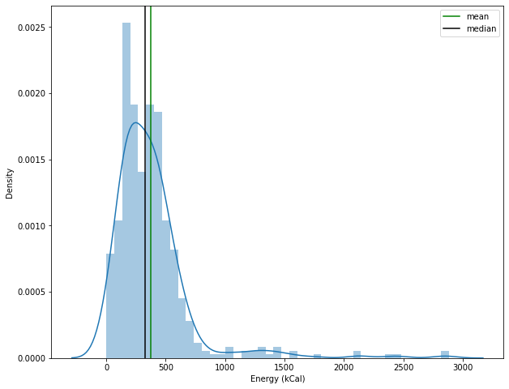

```python
plt.figure(figsize=(10,8))
sns.distplot(df['Energy (kCal)'])
plt.axvline(df['Energy (kCal)'].mean(),color='green',label='mean')
plt.axvline(df['Energy (kCal)'].median(),color='black',label='median')
plt.legend()
plt.show()
```

```python
# importing skew library for skweness in data
from scipy.stats import skew
```

```python
# passing a variable
skew(x['Carbohydrates (g)'])
```

```
0.19005035587527114
```

```
Carbohydrates (g)
0.19005035587527114
```

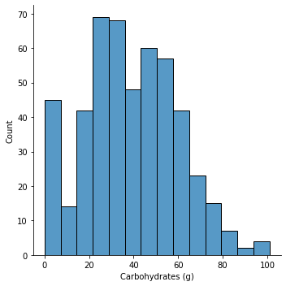

```
Protein (g)
2.558745465956113
```

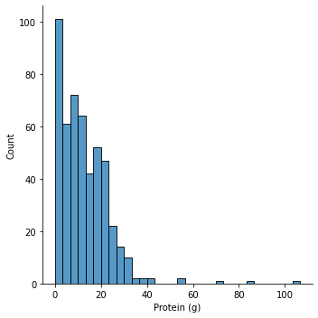

```
Fiber (g)
3.852883734091306
```

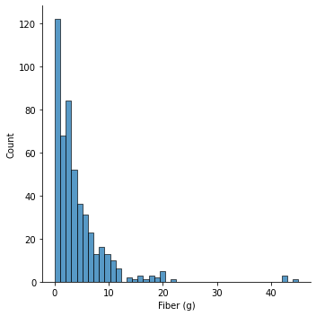

```
Sugar (g)
1.8034706267995593
```

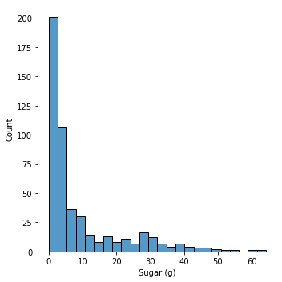

```
Total Fat (g)
0.6314509099038365
```

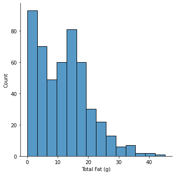

```
Saturated Fat (g)
1.3175074314559376
```

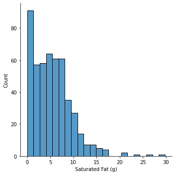

```
Trans Fat (g)
22.154365726865322
```

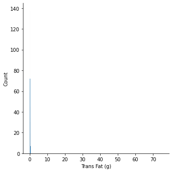

```
Cholesterol (mg)
6.499744889880286
```

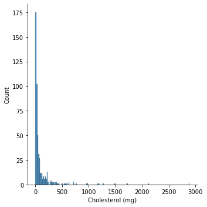

```
Sodium (mg)
0.9856142012782038
```

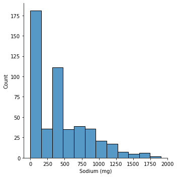

```python
# by using foreloop making a plot to see skewnees in data
for i in x[columns]:
    print(i)
    print(skew(x[i]))

    plt.figure()
    sns.displot(x[i])
    plt.show()
```

```python
# concatenateing the x and y data and seeing the correlation in it
z=pd.concat([x,y],axis=1).corr().style.background_gradient()
print(("*")*125)
print("\t\t\t\t**************ANALYSIS***************\n\n By Checking the correlation in data with energy we will get a knowledge about the columns with is useful or not for our analysis ")
print(("*")*125)
z
```

```
				**************ANALYSIS***************

 By Checking the correlation in data with energy we will get a knowledge about the columns with is useful or not for our analysis
```

|  | Carbohydrates (g) | Protein (g) | Fiber (g) | Sugar (g) | Total Fat (g) | Saturated Fat (g) | Trans Fat (g) | Cholesterol (mg) | Sodium (mg) | Energy (kCal) |
| --- | --- | --- | --- | --- | --- | --- | --- | --- | --- | --- |
| Carbohydrates (g) | 1.000000 | 0.373758 | 0.251971 | 0.089793 | 0.520975 | 0.477955 | -0.073546 | 0.179269 | 0.439178 | 0.793725 |
| Protein (g) | 0.373758 | 1.000000 | 0.409189 | -0.368649 | 0.625332 | 0.453053 | 0.057743 | 0.307488 | 0.399346 | 0.731348 |
| Fiber (g) | 0.251971 | 0.409189 | 1.000000 | -0.310810 | 0.396533 | 0.420586 | -0.014613 | 0.298637 | -0.048133 | 0.421544 |
| Sugar (g) | 0.089793 | -0.368649 | -0.310810 | 1.000000 | -0.259167 | -0.134196 | -0.030530 | -0.078429 | -0.346945 | -0.176766 |
| Total Fat (g) | 0.520975 | 0.625332 | 0.396533 | -0.259167 | 1.000000 | 0.835466 | 0.098290 | 0.299707 | 0.433793 | 0.846733 |
| Saturated Fat (g) | 0.477955 | 0.453053 | 0.420586 | -0.134196 | 0.835466 | 1.000000 | -0.043435 | 0.292733 | 0.281614 | 0.716329 |
| Trans Fat (g) | -0.073546 | 0.057743 | -0.014613 | -0.030530 | 0.098290 | -0.043435 | 1.000000 | -0.014909 | 0.099243 | 0.034969 |
| Cholesterol (mg) | 0.179269 | 0.307488 | 0.298637 | -0.078429 | 0.299707 | 0.292733 | -0.014909 | 1.000000 | -0.066353 | 0.293305 |
| Sodium (mg) | 0.439178 | 0.399346 | -0.048133 | -0.346945 | 0.433793 | 0.281614 | 0.099243 | -0.066353 | 1.000000 | 0.492591 |
| Energy (kCal) | 0.793725 | 0.731348 | 0.421544 | -0.176766 | 0.846733 | 0.716329 | 0.034969 | 0.293305 | 0.492591 | 1.000000 |

```python
# after the correlation we get a result as Trans Fat (g) have a very low correlation with our targeted columns energy
x['Trans Fat (g)']=np.log(x['Trans Fat (g)'])
```

```python
# checkinhg the value of skeweness in Trans Fat (g)
skew(x['Trans Fat (g)'])
```

```
nan
```

```python
# dropping the categorical columns
x.drop(['Company','Category','Product','Per Serve Size'], axis=1, inplace=True)
```

```python
df.info()
```

```
<class 'pandas.core.frame.DataFrame'>
RangeIndex: 530 entries, 0 to 529
Data columns (total 14 columns):
 #   Column             Non-Null Count  Dtype
---  ------             --------------  -----
 0   Company            530 non-null    object
 1   Category           530 non-null    object
 2   Product            530 non-null    object
 3   Per Serve Size     530 non-null    object
 4   Energy (kCal)      530 non-null    float64
 5   Carbohydrates (g)  530 non-null    float64
 6   Protein (g)        530 non-null    float64
 7   Fiber (g)          530 non-null    float64
 8   Sugar (g)          530 non-null    float64
 9   Total Fat (g)      530 non-null    float64
 10  Saturated Fat (g)  530 non-null    float64
 11  Trans Fat (g)      530 non-null    float64
 12  Cholesterol (mg)   530 non-null    float64
 13  Sodium (mg)        530 non-null    float64
dtypes: float64(10), object(4)
memory usage: 58.1+ KB
```

```python
# Converting the dtypes of all columns from float to integer
x["Protein (g)"] = x["Protein (g)"].astype(int)

x["Carbohydrates (g)"] = x["Carbohydrates (g)"].astype(int)

x["Fiber (g)"] = x["Fiber (g)"].astype(int)

x["Sugar (g)"] = x["Sugar (g)"].astype(int)

x["Total Fat (g)"] = x["Total Fat (g)"].astype(int)

x["Saturated Fat (g)"] = x["Saturated Fat (g)"].astype(int)

x['Sodium (mg)'] = x['Sodium (mg)'].astype(int)
```

```python
# Dropping the unnecessary columns
x.drop('Cholesterol (mg)', axis=1, inplace=True)
x.drop('Trans Fat (g)', axis=1, inplace=True)
```

```python
# Filling the null if any with mean values
x.fillna(x.mean(), inplace=True)
```

```python
# Checking he values of our Variable columns
x.info()
```

```
<class 'pandas.core.frame.DataFrame'>
Int64Index: 496 entries, 0 to 529
Data columns (total 7 columns):
 #   Column             Non-Null Count  Dtype
---  ------             --------------  -----
 0   Carbohydrates (g)  496 non-null    int32
 1   Protein (g)        496 non-null    int32
 2   Fiber (g)          496 non-null    int32
 3   Sugar (g)          496 non-null    int32
 4   Total Fat (g)      496 non-null    int32
 5   Saturated Fat (g)  496 non-null    int32
 6   Sodium (mg)        496 non-null    int32
dtypes: int32(7)
memory usage: 17.4 KB
```

# 8. MACHINE LEARNING STARTED

# Split the data into training and testing

```python
# Importing sklearn library to split our data in test and train data
from sklearn.model_selection import train_test_split
xtrain,xtest,ytrain,ytest=train_test_split(x,y,test_size=0.25,random_state=1)
```

```python
# Values of our xtrain
xtrain
```

|  | Carbohydrates (g) | Protein (g) | Fiber (g) | Sugar (g) | Total Fat (g) | Saturated Fat (g) | Sodium (mg) |
| --- | --- | --- | --- | --- | --- | --- | --- |
| 526 | 51 | 26 | 5 | 3 | 13 | 4 | 422 |
| 388 | 52 | 18 | 8 | 0 | 18 | 5 | 0 |
| 81 | 48 | 18 | 3 | 0 | 13 | 5 | 1096 |
| 46 | 66 | 28 | 7 | 0 | 23 | 9 | 1032 |
| 280 | 11 | 6 | 1 | 8 | 7 | 5 | 90 |
| ... | ... | ... | ... | ... | ... | ... | ... |
| 265 | 40 | 5 | 4 | 29 | 17 | 7 | 313 |
| 72 | 51 | 13 | 2 | 0 | 14 | 6 | 732 |
| 430 | 3 | 0 | 2 | 1 | 7 | 1 | 0 |
| 244 | 38 | 20 | 3 | 7 | 22 | 7 | 1132 |
| 37 | 62 | 28 | 9 | 0 | 19 | 10 | 812 |

372 rows × 7 columns

```python
# Values of our xtest
xtest
```

|  | Carbohydrates (g) | Protein (g) | Fiber (g) | Sugar (g) | Total Fat (g) | Saturated Fat (g) | Sodium (mg) |
| --- | --- | --- | --- | --- | --- | --- | --- |
| 381 | 69 | 23 | 11 | 0 | 24 | 10 | 1 |
| 269 | 31 | 11 | 2 | 2 | 11 | 3 | 773 |
| 431 | 2 | 0 | 2 | 1 | 7 | 1 | 0 |
| 354 | 29 | 0 | 0 | 29 | 0 | 0 | 2 |
| 460 | 40 | 11 | 3 | 4 | 5 | 3 | 422 |
| ... | ... | ... | ... | ... | ... | ... | ... |
| 41 | 83 | 32 | 7 | 0 | 24 | 9 | 1534 |
| 148 | 49 | 11 | 7 | 6 | 16 | 5 | 0 |
| 296 | 33 | 6 | 1 | 25 | 5 | 4 | 68 |
| 463 | 40 | 11 | 5 | 4 | 7 | 4 | 422 |
| 306 | 4 | 0 | 0 | 2 | 0 | 0 | 23 |

124 rows × 7 columns

```python
# Values of our ytrain
ytrain
```

```
526    461.200
388    450.600
81     385.980
46     591.940
280    125.250
        ...
265    341.680
72     388.810
430     77.400
244    446.950
37     532.754
Name: Energy (kCal), Length: 372, dtype: float64
```

```python
# Values of our ytest
ytest
```

```
381    587.40
269    278.27
431     73.90
354    119.52
460    254.80
        ...
41     689.23
148    374.10
296    214.21
463    211.90
306     11.49
Name: Energy (kCal), Length: 124, dtype: float64
```

## 1 - Predicting the data using Linear Regression

```python
# Importing the LinearRegression library from sklearn
from sklearn.linear_model import LinearRegression

# assigning a variable as lr
lr=LinearRegression()

#fitting the lr with train and test  data
lr.fit(xtrain,ytrain)

# for prdiction of new values of our targeted columns we use below codes
ypred=lr.predict(xtest)
```

```python
# Predecting the new values of our targeted columns
ypred
```

```
array([596.26084829, 274.00641322,  82.17862143, 123.60976606,
       264.17686274, 347.30991938, 148.57320625, 331.65707903,
       206.91872548, 639.81668202, 361.71377803,  58.64326827,
       593.93716947, 563.6464067 , 543.57764773,  83.30077053,
       365.41035587, 238.43684629, 160.91712643, 260.20997985,
       229.3329097 ,  32.55586259, 549.40228358, 407.00188466,
       141.69128915, 131.17244771, 478.71395818, 137.1223049 ,
       532.13649771, 313.68442456, 179.02792907, 228.05143245,
       215.78098249, 199.40104863, 236.76632872, 402.81927711,
       365.84297607, 349.24371641, 510.73201684, 141.5591372 ,
       616.66002988, 470.739506  , 172.7813853 , 196.88410066,
       360.30260858,  28.94307331, 119.70403168, 438.07239095,
       447.52909517, 167.45538515, 358.51482605, 155.06447941,
       165.3329205 , 204.79643782, 366.93585216, 185.24050752,
       427.70099091, 312.79872897, 180.80119209, 166.35368731,
       165.77150388, 369.56012137, 529.23589033, 339.69812791,
       259.62978186, 119.32639493, 158.14775334, 493.80788564,
       372.12783571, 162.93253665, 333.40581537, 548.67084785,
       633.38972729, 233.18632559, 421.02914496, 154.5372062 ,
       144.26863671, 521.05901331, 540.63981618, 235.02779362,
       207.6357401 , 164.40106693, 109.24873375,  84.151623  ,
       193.46875102, 385.56628373, 132.15639876,  93.93016962,
       449.26147547, 236.76046982, 279.52675856, 414.9510005 ,
       162.22158706, 408.30230972, 166.43072735, 428.42838309,
       412.44724467, 474.40100605, 405.55415074, 174.38356769,
       420.2817281 , 337.8188505 , 404.05006266, 384.05043244,
       289.54772236, 269.31175587, 289.99809328, 463.12780466,
       176.64934665, 192.28810929, 166.53703552, 347.72482549,
        28.94307331, 109.71158702, 230.77376888, 447.33328211,
       461.41798833, 296.35847946,  17.37505596, 679.60383672,
       391.5738029 , 211.42970595, 282.12767358,  32.56172149])
```

### For getting the values as ytest and ypred errors

### For mininizing the errors in our model traing we will use

#### => r2_score

```python
# For checking the ERRORS in our model
print(ytest-ypred)
```

```
381    -8.860848
269     4.263587
431    -8.278621
354    -4.089766
460    -9.376863
         ...
41      9.626163
148   -17.473803
296     2.780294
463   -70.227674
306   -21.071721
Name: Energy (kCal), Length: 124, dtype: float64
```

```python
# Importing the libraries to minimize the errors in our ytest and ypred
from sklearn.metrics import mean_absolute_error,mean_squared_error,r2_score

# Assigning a mae as variable for mean_absolute_error
mae=mean_absolute_error(ytest,ypred)

# Assigning a mse as variable for mean_squared_error
mse=mean_squared_error(ytest,ypred)

# Assigning a rmse as variable for sqrt(mse)
rmse=np.sqrt(mse)

# Assigning a r2 as variable for r2_score
r2=r2_score(ytest,ypred) # this will gives us the accuracy of our model

# Printing the value of all above tests
print(f'mae : {mae}\nmse : {mse}\nrmse : {rmse}\naccuracy : {r2}')
```

```
mae : 27.679073227242192
mse : 2064.0056485238215
rmse : 45.43132893195863
accuracy : 0.9252924078298862
```

# 2 - Predicting the data using Decision Tree

### Decision Tree Regressor

```python
# Importing the library from sklearn for decission tree
from sklearn import tree

# after importing tree we import now our DecisionTreeRegressor
from sklearn.tree import DecisionTreeRegressor
```

```python
# Passing our model train and test data in function
def mymodel(model):
   model.fit(xtrain,ytrain)
   ypred=model.predict(xtest)
   print(r2_score(ytest,ypred))
```

```python
#Assigning a dt as variable for DecisionTreeRegressor
dt=DecisionTreeRegressor()
```

```python
# decission tree will gives each and every time a different accuracy as we run it because it will select random data in operation
mymodel(dt)
```

```
0.9247153283144407
```

## By using Decision Tree we get an accuracy of 92% which is good but lets check whether we get more accurcy by hyper tunning ploting decision tree

#### note :- it will change if we run again that cell BRECAUSE Decission Tree select random sets of data in modeling

# PLOTTING A DECISSION TREE DIAGRAM

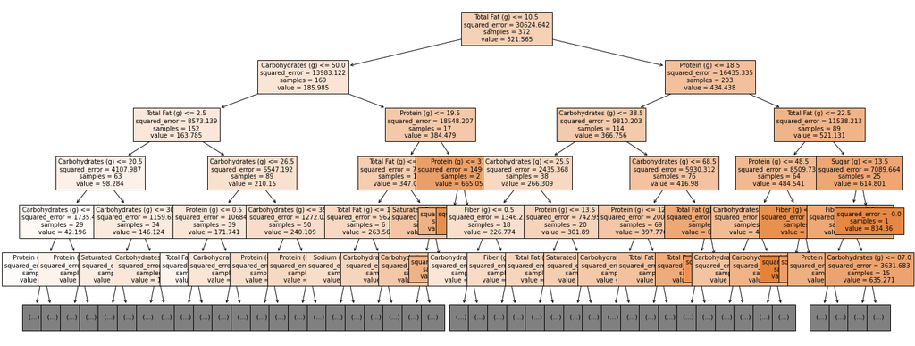

```python
# for ploting a decission tree we use chart
plt.figure(figsize=(25,10))
chart=tree.plot_tree(dt,max_depth=5,feature_names=x.columns,filled=True,fontsize=10)
plt.savefig('abc.jpg')
```

```python
# printing the scores of model  train and test scores
Train = dt.score(xtrain,ytrain)
Test = dt.score(xtest,ytest)
print(f"Train score :{Train}\nTest score : {Test}")
```

```
Train score :0.9999993395402357
Test score : 0.9247153283144407
```

# Train accuracy is high and Test acc is low

# HYPER PARAMETER TUNNING (HPT)

### We use HPT to overcome this problem

### i) - max_depth

```python
# passing train and test data in function to find out our best max depth values
for i in range(1,50):
    dt1= DecisionTreeRegressor(max_depth=i)
    dt1.fit(xtrain,ytrain)
    ypred=dt1.predict(xtest)

    rs=r2_score(ytest,ypred)
    # for printing the scores
    print(f"max_depth {i}  r2_score {rs}")
```

```
max_depth 1  r2_score 0.5271870708762135
max_depth 2  r2_score 0.6339098348619003
max_depth 3  r2_score 0.764050999602308
max_depth 4  r2_score 0.8094927388559904
max_depth 5  r2_score 0.8231146555264548
max_depth 6  r2_score 0.8002582697688422
max_depth 7  r2_score 0.8683290795955451
max_depth 8  r2_score 0.7745802042623913
max_depth 9  r2_score 0.8946539192820187
max_depth 10  r2_score 0.7317852278951993
max_depth 11  r2_score 0.7367655745500289
max_depth 12  r2_score 0.8846919342332171
max_depth 13  r2_score 0.8870516819406651
max_depth 14  r2_score 0.7372225044619193
max_depth 15  r2_score 0.6337608997772108
max_depth 16  r2_score 0.6333017228518265
max_depth 17  r2_score 0.6341219439181449
max_depth 18  r2_score 0.8839114100579901
max_depth 19  r2_score 0.6376388382133565
max_depth 20  r2_score 0.728851470386306
max_depth 21  r2_score 0.9292359130185022
max_depth 22  r2_score 0.7692305717856529
max_depth 23  r2_score 0.8794924313535355
max_depth 24  r2_score 0.633750950381728
max_depth 25  r2_score 0.6339232351278685
max_depth 26  r2_score 0.6249823417996492
max_depth 27  r2_score 0.7360204856359996
max_depth 28  r2_score 0.7439635945711172
max_depth 29  r2_score 0.8885693153870606
max_depth 30  r2_score 0.9229324103056914
max_depth 31  r2_score 0.8899321056859527
max_depth 32  r2_score 0.9244051277910154
max_depth 33  r2_score 0.9287135981398781
max_depth 34  r2_score 0.8981491896099524
max_depth 35  r2_score 0.742130193790042
max_depth 36  r2_score 0.9300587888755472
max_depth 37  r2_score 0.6354805584915952
max_depth 38  r2_score 0.725183445418291
max_depth 39  r2_score 0.6305912483320999
max_depth 40  r2_score 0.6300125184237084
max_depth 41  r2_score 0.8851756668258632
max_depth 42  r2_score 0.7689179551582419
max_depth 43  r2_score 0.7242478358002622
max_depth 44  r2_score 0.6253340184743645
max_depth 45  r2_score 0.7303261883118555
max_depth 46  r2_score 0.7267212131144802
max_depth 47  r2_score 0.6349955175881262
max_depth 48  r2_score 0.6349922915236059
max_depth 49  r2_score 0.6299764207688215
```

```python
# for new accuracy from model by max_depth
dt2=DecisionTreeRegressor(max_depth=3)
mymodel(dt2)
```

```
0.764050999602308
```

#### For Train data accuracy

```python
# Accuracy after passing xtrain and ytrain data
dt2.score(xtrain,ytrain)
```

```
0.8030701983481692
```

#### For Test data accuracy

```python
# Accuracy after passing xtest and ytest data
dt2.score(xtest,ytest)
```

```
0.764050999602308
```

### ii) - min_samples_split

```python
# by using foreloop passing train and test data for accuracy of model
for i in range(2,50):
    dt3= DecisionTreeRegressor(min_samples_split=i)
    dt3.fit(xtrain,ytrain)
    ypred=dt3.predict(xtest)

    rs=r2_score(ytest,ypred)

    print(f"min_samples_split {i}  r2_score {rs}")
```

```
min_samples_split 2  r2_score 0.7255119090806075
min_samples_split 3  r2_score 0.8468486630829838
min_samples_split 4  r2_score 0.8456562966751583
min_samples_split 5  r2_score 0.8494885271422303
min_samples_split 6  r2_score 0.8432330912009786
min_samples_split 7  r2_score 0.8399521374058625
min_samples_split 8  r2_score 0.8403814803719412
min_samples_split 9  r2_score 0.8359287585630624
min_samples_split 10  r2_score 0.8369514357875105
min_samples_split 11  r2_score 0.8372514210666839
min_samples_split 12  r2_score 0.8315425936152608
min_samples_split 13  r2_score 0.8299733374803027
min_samples_split 14  r2_score 0.8284359616854289
min_samples_split 15  r2_score 0.8281660023685262
min_samples_split 16  r2_score 0.8275671201715509
min_samples_split 17  r2_score 0.8252966268511412
min_samples_split 18  r2_score 0.8459093887706515
min_samples_split 19  r2_score 0.8498073564657025
min_samples_split 20  r2_score 0.8499826995517079
min_samples_split 21  r2_score 0.8509584388775211
min_samples_split 22  r2_score 0.8500313296186686
min_samples_split 23  r2_score 0.8425043652104843
min_samples_split 24  r2_score 0.8425043652104843
min_samples_split 25  r2_score 0.8369686745797913
min_samples_split 26  r2_score 0.8356071241317151
min_samples_split 27  r2_score 0.8341902728408115
min_samples_split 28  r2_score 0.8341902728408115
min_samples_split 29  r2_score 0.8329693380442329
min_samples_split 30  r2_score 0.830560974755661
min_samples_split 31  r2_score 0.830560974755661
min_samples_split 32  r2_score 0.830560974755661
min_samples_split 33  r2_score 0.830560974755661
min_samples_split 34  r2_score 0.8168259840694909
min_samples_split 35  r2_score 0.8183142089515902
min_samples_split 36  r2_score 0.8183142089515902
min_samples_split 37  r2_score 0.8662976359862793
min_samples_split 38  r2_score 0.8662976359862793
min_samples_split 39  r2_score 0.8552930323318655
min_samples_split 40  r2_score 0.8524808593076726
min_samples_split 41  r2_score 0.8524808593076726
min_samples_split 42  r2_score 0.8524808593076726
min_samples_split 43  r2_score 0.8524808593076725
min_samples_split 44  r2_score 0.8524808593076726
min_samples_split 45  r2_score 0.8524808593076725
min_samples_split 46  r2_score 0.8524808593076726
min_samples_split 47  r2_score 0.8524808593076725
min_samples_split 48  r2_score 0.8524808593076726
min_samples_split 49  r2_score 0.8524808593076726
```

```python
# for new accuracy from model by min_samples_split methods
dt4=DecisionTreeRegressor(min_samples_split=4)
mymodel(dt4)
```

```
0.8464578697365717
```

```python
# Accuracy after passing xtrain and ytrain data
dt4.score(xtrain,ytrain)
```

```
0.9740628627277446
```

```python
# Accuracy after passing xtest and ytest data
dt4.score(xtest,ytest)
```

[output not shown]